# Research_Scientist_Interview_Yash_Manish_Raichura

### Exploratory Data Analysis for the different medicines files ( FENOFIBRATE , MONTELUKAST and ZOLPIDEM)

```python
print("Shape of the different medicine files : ")

print("FENOFIBRATE : ")
print(df_feno.shape)
print()
print("MONTELUKAST :")
print(df_mont.shape)
print()
print("ZOLPIDEM :")
print(df_zolp.shape)
```

```
Shape of the different medicine files :
FENOFIBRATE :
(473630, 3)

MONTELUKAST :
(397077, 3)

ZOLPIDEM :
(702195, 3)
```

```python
#Renaming the columns in the medicine files for consistency as in the problem statement we have rxlen but in some
#of the files we have days.
#Keeping consistent column names

df_feno.rename(columns = {'days' : 'rxlen'}, inplace = True)
df_mont.rename(columns = {'days' : 'rxlen'}, inplace = True)
df_zolp.rename(columns = {'days' : 'rxlen'}, inplace = True)

# In order to identify what is the type of medicine that is being given, added a drug column that stores the medicine name
#for further analysis.

df_feno['drug'] = 'feno'
df_mont['drug'] = 'mont'
df_zolp['drug'] = 'zolp'
```

```python
#Concatinating the 3 medicine dataframes into 1 for further detailed analysis
frames = [df_feno, df_mont, df_zolp]
df_drugs=pd.concat(frames)
```

```python
#Checking for the top 10 rows in the combined medicine file
df_drugs.head(10)
```

|  | ptid | time | rxlen | drug |
| --- | --- | --- | --- | --- |
| 0 | 00015cf54240bbcbaf5a8c39a258a63fc7daf0c1cc2e4883ef2f5307fee0b327 | -125 | 30.00000 | feno |
| 1 | 00015cf54240bbcbaf5a8c39a258a63fc7daf0c1cc2e4883ef2f5307fee0b327 | -153 | 30.00000 | feno |
| 2 | 00015cf54240bbcbaf5a8c39a258a63fc7daf0c1cc2e4883ef2f5307fee0b327 | -19 | 90.00000 | feno |
| 3 | 00015cf54240bbcbaf5a8c39a258a63fc7daf0c1cc2e4883ef2f5307fee0b327 | -205 | 30.00000 | feno |
| 4 | 00015cf54240bbcbaf5a8c39a258a63fc7daf0c1cc2e4883ef2f5307fee0b327 | -82 | 90.00000 | feno |
| 5 | 00015cf54240bbcbaf5a8c39a258a63fc7daf0c1cc2e4883ef2f5307fee0b327 | -86 | 90.00000 | feno |
| 6 | 00015cf54240bbcbaf5a8c39a258a63fc7daf0c1cc2e4883ef2f5307fee0b327 | 28 | 90.00000 | feno |
| 7 | 00015cf54240bbcbaf5a8c39a258a63fc7daf0c1cc2e4883ef2f5307fee0b327 | 352 | 90.00000 | feno |
| 8 | 00015cf54240bbcbaf5a8c39a258a63fc7daf0c1cc2e4883ef2f5307fee0b327 | 438 | 30.00000 | feno |
| 9 | 00015cf54240bbcbaf5a8c39a258a63fc7daf0c1cc2e4883ef2f5307fee0b327 | 481 | 30.00000 | feno |

```python
#Checking for the bottom 10 rows in the medicine file
df_drugs.tail(10)
```

|  | ptid | time | rxlen | drug |
| --- | --- | --- | --- | --- |
| 702185 | fffb96ffce368a4984462523bc8aace039c21b3ffe10567e6c1b93029a6c158c | 600 | 30.00000 | zolp |
| 702186 | fffb96ffce368a4984462523bc8aace039c21b3ffe10567e6c1b93029a6c158c | 656 | 30.00000 | zolp |
| 702187 | fffb96ffce368a4984462523bc8aace039c21b3ffe10567e6c1b93029a6c158c | 665 | 30.00000 | zolp |
| 702188 | fffb96ffce368a4984462523bc8aace039c21b3ffe10567e6c1b93029a6c158c | 684 | 30.00000 | zolp |
| 702189 | fffb96ffce368a4984462523bc8aace039c21b3ffe10567e6c1b93029a6c158c | 710 | 30.00000 | zolp |
| 702190 | fffbc713e33be24058779c6ec771d4f3edd6a5fabc3276410325461abca7d277 | -304 | 14.00000 | zolp |
| 702191 | fffbc713e33be24058779c6ec771d4f3edd6a5fabc3276410325461abca7d277 | -365 | 14.00000 | zolp |
| 702192 | fffbc713e33be24058779c6ec771d4f3edd6a5fabc3276410325461abca7d277 | -385 | 14.00000 | zolp |
| 702193 | fffbc713e33be24058779c6ec771d4f3edd6a5fabc3276410325461abca7d277 | -398 | 14.00000 | zolp |
| 702194 | ffff23210b3254560e272dee6bbd0b93a4ef81a81bb722f6bdbbd83165b1b537 | 415 | 30.00000 | zolp |

```python
print("Combined Medicine file shape :")
print(df_drugs.shape)
```

```
Combined Medicine file shape :
(1572902, 4)
```

```python
# Checking for the unique patient records in the combined medicine file
print('Number of unique patients in combined medicine file : ',len(df_drugs.ptid.unique()))

# Comparing the number of unique patients with the total number of patients
print('Number of records in df_drugs: ',len(df_drugs))
```

```
Number of unique patients in combined medicine file :  114938
Number of records in df_drugs:  1572902
```

#### It was observed that there are lesser unique patient records in the medicine file as compared to the total number of records.

```python
# theory - taking -30, medicine started before dm2, so no record if effect on dr, taken for other symptoms
df_drugs = df_drugs[df_drugs.time > -30]
df_drugs = df_drugs.reset_index().drop(columns = 'index')
```

#### If the patient has already been prescribed any of the 3 given medicines even before the diagnosis of DM2, which implies that the medicine was taken for some other symptom and also, the problem statement suggested to ignore records with time <-30

```python
#Find number of unique patients in the medicine file

print('Number of unique patients in combined medicine file: ',len(df_drugs.ptid.unique()))

#Comparing the count of unique patients with the length of df_patient

print('Number of patient records in combined medicine file: ',len(df_drugs))

#Theory: all rows are unique
```

```
Number of unique patients in combined medicine file:  91420
Number of patient records in combined medicine file:  1074398
```

```python
#Checking for datatypes of the combined medicine file
df_drugs.info()
```

```
<class 'pandas.core.frame.DataFrame'>
RangeIndex: 1074398 entries, 0 to 1074397
Data columns (total 4 columns):
ptid     1074398 non-null object
time     1074398 non-null int64
rxlen    1073952 non-null float64
drug     1074398 non-null object
dtypes: float64(1), int64(1), object(2)
memory usage: 32.8+ MB
```

```python
# Summary statistics of the combined medicine file for the time(time from the date when DM2 was recorded and fill date)
#and rxlen(indicating the number of days the medicine was prescribed for), columns for further detailed analysis like
#finding the mean, median , standard deviation, various quartiles and min max values.

df_drugs.describe()
```

|  | time | rxlen |
| --- | --- | --- |
| count | 1074398.00000 | 1073952.00000 |
| mean | 664.19785 | 39.93065 |
| std | 558.09648 | 25.51164 |
| min | -29.00000 | 0.00000 |
| 25% | 252.00000 | 30.00000 |
| 50% | 584.00000 | 30.00000 |
| 75% | 1004.00000 | 30.00000 |
| max | 30157.00000 | 999.00000 |

```python
#Checking for NA values in the combined medicine file
df_drugs.isna().sum()
```

```
ptid       0
time       0
rxlen    446
drug       0
dtype: int64
```

#### It was observed that there are 446 null values in the medicine file in the rxlen column , indicating that the prescription was not filled for those patients. Upon investigating further, except 8 of these 446 records, others were true duplicates which had every column value the same, and rxlen was null for one of these duplicates and was mentioned in the other reccord. We will impute these nulls later on in the best way possible

```python
#Retriveing rows with values of rxlen as null
df_drugs[pd.isnull(df_drugs).any(axis=1)]
```

|  | ptid | time | rxlen | drug |
| --- | --- | --- | --- | --- |
| 1596 | 011249b0bd5598e4c4dc4451ad029fc92c494b2db5730b0f9f96a6c4e60d606e | 521 | nan | feno |
| 1601 | 011249b0bd5598e4c4dc4451ad029fc92c494b2db5730b0f9f96a6c4e60d606e | 73 | nan | feno |
| 1603 | 011249b0bd5598e4c4dc4451ad029fc92c494b2db5730b0f9f96a6c4e60d606e | 736 | nan | feno |
| 5683 | 03903692e27e78e1b8081c8de1a1d87ce09f5046a9d31cb1f04904c56cb092f5 | 980 | nan | feno |
| 14026 | 094f44de3498d117048bedddf3f5f8a096f870a6127a63814377113ca61b7a0b | 455 | nan | feno |
| ... | ... | ... | ... | ... |
| 1064494 | fa8418c4ad2656a4e2ddb1641038a2a068d35500b9b7d65811f2c1efd4a665bd | 471 | nan | zolp |
| 1064496 | fa8418c4ad2656a4e2ddb1641038a2a068d35500b9b7d65811f2c1efd4a665bd | 502 | nan | zolp |
| 1067400 | fc1b48224c6b22fd878868e9a6d47223a90e1c36e1717cb4fba8a1032811391c | 1346 | nan | zolp |
| 1068872 | fcf8b349c41b613e7eae2ed8ecd1368d4e9aee2a955c0037f3781445098b5e51 | 537 | nan | zolp |
| 1071832 | fe77cb393b7bef3b07c186b0c1a419871ee00d73bec4a9527a0da396aefe1338 | 78 | nan | zolp |

446 rows × 4 columns

```python
#Creating dummy variable for the drug column to distinguish between the different treatment groups and study the
#roles of these medicines for their protective effect on development of DR.

df_drugs = pd.get_dummies(df_drugs, columns = ['drug'])
df_drugs = df_drugs.reset_index().drop(columns = ['index'])

# Sorting the combined medicine file by ptid and time and resetting the index too.
df_drugs.sort_values(by=['ptid', 'time'], inplace = True)
df_drugs = df_drugs.reset_index().drop(columns = ['index'])

#Checking for the top 10 rows
df_drugs.head()
```

|  | ptid | time | rxlen | drug_feno | drug_mont | drug_zolp |
| --- | --- | --- | --- | --- | --- | --- |
| 0 | 000019eb05045d9c5a1843eebd4cf9f68d550f466091e88dffaab391ff63f54b | 192 | 30.00000 | 0 | 0 | 1 |
| 1 | 000019eb05045d9c5a1843eebd4cf9f68d550f466091e88dffaab391ff63f54b | 215 | 30.00000 | 0 | 0 | 1 |
| 2 | 000019eb05045d9c5a1843eebd4cf9f68d550f466091e88dffaab391ff63f54b | 298 | 30.00000 | 0 | 0 | 1 |
| 3 | 0001480f995ecb1fb19c2f6cce0d3b1730f6538213763c0954d3fc3fda6f19d9 | -7 | 30.00000 | 0 | 1 | 0 |
| 4 | 0001480f995ecb1fb19c2f6cce0d3b1730f6538213763c0954d3fc3fda6f19d9 | 20 | 90.00000 | 0 | 1 | 0 |

```python
# Calculating the means of the prescription times for each of the 3 drugs to get an estimate of the average time
# of the medicine prescribed to each patient

print('rxlen average for feno drug - ',df_drugs[df_drugs.drug_feno == 1].rxlen.mean())
print('rxlen average for mont drug - ',df_drugs[df_drugs.drug_mont == 1].rxlen.mean())
print('rxlen average for zolp drug - ',df_drugs[df_drugs.drug_zolp == 1].rxlen.mean())
```

```
rxlen average for feno drug -  48.8924196693358
rxlen average for mont drug -  45.528525660159595
rxlen average for zolp drug -  29.059584696293353
```

```python
# Renaming time column of df_drugs to start
df_drugs.rename(columns = {'time': 'start'}, inplace = True)

# Merging the medicine file and patient file using a left outer join on ptid columns of both df_drugs and df_patient to get the
#age, event and gender column for each of the patient on a prescription

df_merged = df_drugs.merge(df_patient, how= 'left', on = 'ptid')
df_merged.head()
```

|  | ptid | start | rxlen | drug_feno | drug_mont | drug_zolp | time | event | gender | age |
| --- | --- | --- | --- | --- | --- | --- | --- | --- | --- | --- |
| 0 | 000019eb05045d9c5a1843eebd4cf9f68d550f466091e88dffaab391ff63f54b | 192 | 30.00000 | 0 | 0 | 1 | 1057 | 1 | M | 65 |
| 1 | 000019eb05045d9c5a1843eebd4cf9f68d550f466091e88dffaab391ff63f54b | 215 | 30.00000 | 0 | 0 | 1 | 1057 | 1 | M | 65 |
| 2 | 000019eb05045d9c5a1843eebd4cf9f68d550f466091e88dffaab391ff63f54b | 298 | 30.00000 | 0 | 0 | 1 | 1057 | 1 | M | 65 |
| 3 | 0001480f995ecb1fb19c2f6cce0d3b1730f6538213763c0954d3fc3fda6f19d9 | -7 | 30.00000 | 0 | 1 | 0 | 697 | 0 | F | 65 |
| 4 | 0001480f995ecb1fb19c2f6cce0d3b1730f6538213763c0954d3fc3fda6f19d9 | 20 | 90.00000 | 0 | 1 | 0 | 697 | 0 | F | 65 |

#### The time column is the number of days between first DM2 recorded and first DR recorded (or last followup date if not DR recorded) and the start column indicates the time from first DM2 or dAMD to fill date. Hence the start column cannot be more than the time column and hence these records need to be dropped

```python
#Selecting rows where start is greater than time

df_merged[df_merged.start > df_merged.time]
```

|  | ptid | start | rxlen | drug_feno | drug_mont | drug_zolp | time | event | gender | age |
| --- | --- | --- | --- | --- | --- | --- | --- | --- | --- | --- |
| 78 | 0004e9a9dad84904fcdc11cb337d30da9035340c2c63ff6d136067778e3c7047 | 105 | 30.00000 | 0 | 0 | 1 | 84 | 1 | F | 44 |
| 79 | 0004e9a9dad84904fcdc11cb337d30da9035340c2c63ff6d136067778e3c7047 | 159 | 30.00000 | 0 | 0 | 1 | 84 | 1 | F | 44 |
| 80 | 0004e9a9dad84904fcdc11cb337d30da9035340c2c63ff6d136067778e3c7047 | 211 | 30.00000 | 0 | 0 | 1 | 84 | 1 | F | 44 |
| 81 | 0004e9a9dad84904fcdc11cb337d30da9035340c2c63ff6d136067778e3c7047 | 287 | 30.00000 | 0 | 0 | 1 | 84 | 1 | F | 44 |
| 82 | 0004e9a9dad84904fcdc11cb337d30da9035340c2c63ff6d136067778e3c7047 | 325 | 30.00000 | 0 | 0 | 1 | 84 | 1 | F | 44 |
| ... | ... | ... | ... | ... | ... | ... | ... | ... | ... | ... |
| 1074376 | ffff4eae44c905d407aac208f3008e7ccbb2ec16d086ea4d4b15eaa66337600e | 614 | 28.00000 | 1 | 0 | 0 | 462 | 1 | M | 75 |
| 1074377 | ffff4eae44c905d407aac208f3008e7ccbb2ec16d086ea4d4b15eaa66337600e | 725 | 7.00000 | 1 | 0 | 0 | 462 | 1 | M | 75 |
| 1074378 | ffff4eae44c905d407aac208f3008e7ccbb2ec16d086ea4d4b15eaa66337600e | 731 | 7.00000 | 1 | 0 | 0 | 462 | 1 | M | 75 |
| 1074379 | ffff4eae44c905d407aac208f3008e7ccbb2ec16d086ea4d4b15eaa66337600e | 737 | 7.00000 | 1 | 0 | 0 | 462 | 1 | M | 75 |
| 1074380 | ffff4eae44c905d407aac208f3008e7ccbb2ec16d086ea4d4b15eaa66337600e | 744 | 30.00000 | 1 | 0 | 0 | 462 | 1 | M | 75 |

200417 rows × 10 columns

```python
# Checking how many unique patients will be dropped, patients here have multiple records, so patients are not dropped
len(df_merged[df_merged.start > df_merged.time].ptid.unique())
```

```
30750
```

```python
# Dropping the records with start value being greater than time
df_merged.drop(df_merged[df_merged.start > df_merged.time].index, inplace = True)
```

```python
#To create a dataframe usable for Cox Regression, we need a start and an end column.We first group the dataframe by ptid
# and use the shift function on the start column to retrive the next available row for a particular ptid. This value is populated
# in the stop column

df_merged['stop'] = df_merged.groupby(['ptid'])['start'].shift(-1)
```

```python
# By purusing the above method, the last record for each patient will have a stop value of NA and this needs to be populated
# by the time column which suggests the last follow up date or the day when DR was recorded which marks the end of timeline for
#our analysis
df_merged.stop.fillna(df_merged.time, inplace = True)
```

```python
#Now that we have defined the boundaries using start and stop column and have utilised the time column to do the same, we drop
#the time column
df_merged.drop(columns = 'time', inplace = True)
df_merged.head()
```

|  | ptid | start | rxlen | drug_feno | drug_mont | drug_zolp | event | gender | age | stop |
| --- | --- | --- | --- | --- | --- | --- | --- | --- | --- | --- |
| 0 | 000019eb05045d9c5a1843eebd4cf9f68d550f466091e88dffaab391ff63f54b | 192 | 30.00000 | 0 | 0 | 1 | 1 | M | 65 | 215.00000 |
| 1 | 000019eb05045d9c5a1843eebd4cf9f68d550f466091e88dffaab391ff63f54b | 215 | 30.00000 | 0 | 0 | 1 | 1 | M | 65 | 298.00000 |
| 2 | 000019eb05045d9c5a1843eebd4cf9f68d550f466091e88dffaab391ff63f54b | 298 | 30.00000 | 0 | 0 | 1 | 1 | M | 65 | 1057.00000 |
| 3 | 0001480f995ecb1fb19c2f6cce0d3b1730f6538213763c0954d3fc3fda6f19d9 | -7 | 30.00000 | 0 | 1 | 0 | 0 | F | 65 | 20.00000 |
| 4 | 0001480f995ecb1fb19c2f6cce0d3b1730f6538213763c0954d3fc3fda6f19d9 | 20 | 90.00000 | 0 | 1 | 0 | 0 | F | 65 | 113.00000 |

```python
#age column is also an object and not a numeric value and since we do not know what MI indicates as age and also since out of
#873981 records in total, only 22 unique patients and total 134 records have their age recorded as MI, we drop these rows.

print('number of unique patients with gender = MI ',len(df_merged[df_merged.age == 'MI'].ptid.unique()))
df_merged[df_merged.age == 'MI']
```

```
number of unique patients with gender = MI  22
```

|  | ptid | start | rxlen | drug_feno | drug_mont | drug_zolp | event | gender | age | stop |
| --- | --- | --- | --- | --- | --- | --- | --- | --- | --- | --- |
| 24848 | 05e76f341a066f7d8fccd74138f6c3e2f9915480255aab8414e128bb836e8ccc | 133 | 30.00000 | 0 | 0 | 1 | 0 | F | MI | 164.00000 |
| 24849 | 05e76f341a066f7d8fccd74138f6c3e2f9915480255aab8414e128bb836e8ccc | 164 | 30.00000 | 0 | 0 | 1 | 0 | F | MI | 191.00000 |
| 24850 | 05e76f341a066f7d8fccd74138f6c3e2f9915480255aab8414e128bb836e8ccc | 191 | 30.00000 | 0 | 0 | 1 | 0 | F | MI | 226.00000 |
| 24851 | 05e76f341a066f7d8fccd74138f6c3e2f9915480255aab8414e128bb836e8ccc | 226 | 30.00000 | 0 | 0 | 1 | 0 | F | MI | 252.00000 |
| 24852 | 05e76f341a066f7d8fccd74138f6c3e2f9915480255aab8414e128bb836e8ccc | 252 | 30.00000 | 0 | 0 | 1 | 0 | F | MI | 254.00000 |
| ... | ... | ... | ... | ... | ... | ... | ... | ... | ... | ... |
| 1064779 | fdd2bbfc45780e3204bf731c3d580d9cca6b90be86fb438f32339bcc0a687680 | 506 | 30.00000 | 0 | 0 | 1 | 0 | F | MI | 539.00000 |
| 1064780 | fdd2bbfc45780e3204bf731c3d580d9cca6b90be86fb438f32339bcc0a687680 | 539 | 30.00000 | 0 | 0 | 1 | 0 | F | MI | 565.00000 |
| 1064781 | fdd2bbfc45780e3204bf731c3d580d9cca6b90be86fb438f32339bcc0a687680 | 565 | 30.00000 | 0 | 0 | 1 | 0 | F | MI | 588.00000 |
| 1064782 | fdd2bbfc45780e3204bf731c3d580d9cca6b90be86fb438f32339bcc0a687680 | 588 | 30.00000 | 0 | 0 | 1 | 0 | F | MI | 595.00000 |
| 1068712 | fec16f455d3c07f818c30dd5f3d109939860266a5a81b1bb8f22994c5afed805 | 1485 | 90.00000 | 0 | 0 | 1 | 0 | F | MI | 1515.00000 |

134 rows × 10 columns

```python
#dropping age with values = MI
df_merged.drop(df_merged[df_merged.age == 'MI'].index.tolist(), inplace = True)
```

```python
# Checking for rxlen nulls - 402 nulls
df_merged.isna().sum()
```

```
ptid           0
start          0
rxlen        402
drug_feno      0
drug_mont      0
drug_zolp      0
event          0
gender         0
age            0
stop           0
dtype: int64
```

```python
# Retrieving rows with rxlen as null
df_merged[pd.isnull(df_merged).any(axis=1)]
```

|  | ptid | start | rxlen | drug_feno | drug_mont | drug_zolp | event | gender | age | stop |
| --- | --- | --- | --- | --- | --- | --- | --- | --- | --- | --- |
| 740 | 0022fda8e8a0c4290d2a3b3cdf66baa5027cef8b5958672e7ce8eec3cf9c9c7c | 18 | nan | 0 | 0 | 1 | 0 | F | 65 | 18.00000 |
| 4761 | 011249b0bd5598e4c4dc4451ad029fc92c494b2db5730b0f9f96a6c4e60d606e | 73 | nan | 1 | 0 | 0 | 0 | M | 48 | 73.00000 |
| 4772 | 011249b0bd5598e4c4dc4451ad029fc92c494b2db5730b0f9f96a6c4e60d606e | 521 | nan | 1 | 0 | 0 | 0 | M | 48 | 521.00000 |
| 4777 | 011249b0bd5598e4c4dc4451ad029fc92c494b2db5730b0f9f96a6c4e60d606e | 736 | nan | 1 | 0 | 0 | 0 | M | 48 | 736.00000 |
| 9211 | 0228d37384ccf8e364e07e1fd23aa755c2eab7fa22c83cffe259e53ec9ece35c | 1154 | nan | 0 | 0 | 1 | 0 | F | 39 | 1154.00000 |
| ... | ... | ... | ... | ... | ... | ... | ... | ... | ... | ... |
| 1049884 | fa8418c4ad2656a4e2ddb1641038a2a068d35500b9b7d65811f2c1efd4a665bd | 502 | nan | 0 | 0 | 1 | 0 | F | 65 | 502.00000 |
| 1060629 | fcf8b349c41b613e7eae2ed8ecd1368d4e9aee2a955c0037f3781445098b5e51 | 537 | nan | 0 | 0 | 1 | 0 | M | 64 | 537.00000 |
| 1067555 | fe77cb393b7bef3b07c186b0c1a419871ee00d73bec4a9527a0da396aefe1338 | 78 | nan | 0 | 0 | 1 | 1 | F | 75 | 78.00000 |
| 1073616 | ffd0461fa1af0450322f2646746677fe99852e9ecb0585046c15f9308d63acab | 225 | nan | 0 | 1 | 0 | 1 | F | 65 | 225.00000 |
| 1073619 | ffd0461fa1af0450322f2646746677fe99852e9ecb0585046c15f9308d63acab | 249 | nan | 0 | 1 | 0 | 1 | F | 65 | 249.00000 |

402 rows × 10 columns

#### Upon investigating further, we find that rxlen has 402 null values. Instead of dropping them, we closely look at the reasons for this. 394 of the 402 records, are true duplicates, i.e. for the same ptid, start and end time, there is a record with rxlen value and there is another row with no rxlen value. We remove these 394 true duplicates.

#### For the remaining 8 rows, we identify which respective drug was the patient treated with i.e. feno, mont or zolp and create cases such as whether the difference between the start and stop columns was less than 30, between 30 and 90 and greater than 90.

#### For each of these cases we calculate the mean of rxlen and replace it with the corresponding null value of rxlen satisfying the case where the start and stop duration lies between one of the intervals and the drug prescribed is the same

```python
# Identifying 394 true duplicates where rxlen is null and dropping them

print('Number of true duplicates with rxlen being NA - ',len(df_merged[(df_merged['rxlen'].isna()) & (df_merged.start == df_merged.stop)]))
#Dropping the above rows
df_merged.drop(df_merged[(df_merged['rxlen'].isna()) & (df_merged.start == df_merged.stop)].sort_values(by = 'start').index.tolist(), inplace = True)
```

```
Number of true duplicates with rxlen being NA -  394
```

```python
# Retrieving the remaining 8 rows where rxlen is NA
df_merged[pd.isnull(df_merged).any(axis=1)]
```

|  | ptid | start | rxlen | drug_feno | drug_mont | drug_zolp | event | gender | age | stop |
| --- | --- | --- | --- | --- | --- | --- | --- | --- | --- | --- |
| 55199 | 0d2889518dd7c30a0ae6e13e5f8fc1325c2ac7809e0f328ac72cbd436d0f916f | 305 | nan | 0 | 1 | 0 | 0 | F | 75 | 770.00000 |
| 380930 | 5a9f803a21577dc350995f2ff19b7ee2b1e5beb036f05b2e4d3c3484ce0ec855 | 161 | nan | 0 | 0 | 1 | 0 | F | 65 | 283.00000 |
| 380931 | 5a9f803a21577dc350995f2ff19b7ee2b1e5beb036f05b2e4d3c3484ce0ec855 | 283 | nan | 0 | 0 | 1 | 0 | F | 65 | 327.00000 |
| 380932 | 5a9f803a21577dc350995f2ff19b7ee2b1e5beb036f05b2e4d3c3484ce0ec855 | 327 | nan | 0 | 0 | 1 | 0 | F | 65 | 829.00000 |
| 496163 | 75acb333cc61d2962fabc11c941460f2aba08b50fc40c1da29bb23219656aa40 | 1046 | nan | 0 | 1 | 0 | 0 | F | 40 | 1132.00000 |
| 534213 | 7ecaeb0cb3825afd08b6a1f7a514fd0ff48ac3920c2ae45fda02a75021e6cecb | 144 | nan | 0 | 0 | 1 | 0 | F | 48 | 218.00000 |
| 1049530 | fa6e8f14a6efbeb8e03a12cbcc6e75bb8cf3982d2202820a329bc4ad023e2358 | -19 | nan | 1 | 0 | 0 | 0 | F | 65 | 11.00000 |
| 1049531 | fa6e8f14a6efbeb8e03a12cbcc6e75bb8cf3982d2202820a329bc4ad023e2358 | 11 | nan | 1 | 0 | 0 | 0 | F | 65 | 36.00000 |

```python
#As mentioned above, creating a list with means of rxlen for different drugs and (stop-start) intervals

rxlen_missing_list = [round(df_merged[(df_merged.drug_mont == 1) & (df_merged.stop - df_merged.start > 90)].rxlen.mean()),
                      round(df_merged[(df_merged.drug_zolp == 1) & (df_merged.stop - df_merged.start > 90)].rxlen.mean()),
                      round(df_merged[(df_merged.drug_zolp==1) & (df_merged.stop - df_merged.start >30) & (df_merged.stop - df_merged.start<=90 )].rxlen.mean()),
                      round(df_merged[(df_merged.drug_zolp == 1) & (df_merged.stop - df_merged.start > 90)].rxlen.mean()),
                      round(df_merged[(df_merged.drug_mont==1) & (df_merged.stop - df_merged.start >30) & (df_merged.stop - df_merged.start<=90 )].rxlen.mean()),
                      round(df_merged[(df_merged.drug_zolp == 1) & (df_merged.stop - df_merged.start > 90)].rxlen.mean()),
                      round(df_merged[(df_merged.drug_feno == 1) & (df_merged.stop - df_merged.start <= 30)].rxlen.mean()),
                      round(df_merged[(df_merged.drug_feno == 1) & (df_merged.stop - df_merged.start <= 30)].rxlen.mean())
                     ]

#Replacing the missing rxlen values with the above list
df_merged.loc[df_merged.rxlen.isnull(), 'rxlen'] = rxlen_missing_list
```

```python
# Checking for nulls
df_merged.isna().sum()
```

```
ptid         0
start        0
rxlen        0
drug_feno    0
drug_mont    0
drug_zolp    0
event        0
gender       0
age          0
stop         0
dtype: int64
```

#### Since in the age columns, the value 'MI' has already been taken into consideration, there are multiple rows which have their age in days greater than the start and stop interval, i.e. the interval between when a person was recorded with DM2 or a prescription was filed and the day when the patient appeared for a last follow up or recorded first DR. This interval cannot be more than the age of the person in itself. We try to find these records by checking where the (stop-start) interval is greater than the age of the person in days

```python
# Checking for rows where the (stop-start) interval is greater than the age of the person in days
df_merged[((df_merged.stop - df_merged.start) > (df_merged.age.astype(int)*365))]
```

|  | ptid | start | rxlen | drug_feno | drug_mont | drug_zolp | event | gender | age | stop |
| --- | --- | --- | --- | --- | --- | --- | --- | --- | --- | --- |
| 6816 | 019693dbe42478a352b4ac16648a608bd4c331e4bb8ebd9a263a360ff244bf79 | 0 | 30.00000 | 0 | 0 | 1 | 0 | M | 00 | 59.00000 |
| 6817 | 019693dbe42478a352b4ac16648a608bd4c331e4bb8ebd9a263a360ff244bf79 | 59 | 30.00000 | 0 | 0 | 1 | 0 | M | 00 | 87.00000 |
| 6819 | 019693dbe42478a352b4ac16648a608bd4c331e4bb8ebd9a263a360ff244bf79 | 87 | 90.00000 | 0 | 0 | 1 | 0 | M | 00 | 177.00000 |
| 6820 | 019693dbe42478a352b4ac16648a608bd4c331e4bb8ebd9a263a360ff244bf79 | 177 | 90.00000 | 0 | 0 | 1 | 0 | M | 00 | 261.00000 |
| 6821 | 019693dbe42478a352b4ac16648a608bd4c331e4bb8ebd9a263a360ff244bf79 | 261 | 90.00000 | 0 | 0 | 1 | 0 | M | 00 | 367.00000 |
| ... | ... | ... | ... | ... | ... | ... | ... | ... | ... | ... |
| 1069486 | fee800322fb78bd453b697bc42ac4e88765fdd2284d4f460cb2fd8e22d0cd2da | 377 | 90.00000 | 0 | 1 | 0 | 0 | M | 00 | 491.00000 |
| 1069487 | fee800322fb78bd453b697bc42ac4e88765fdd2284d4f460cb2fd8e22d0cd2da | 491 | 90.00000 | 0 | 1 | 0 | 0 | M | 00 | 558.00000 |
| 1069488 | fee800322fb78bd453b697bc42ac4e88765fdd2284d4f460cb2fd8e22d0cd2da | 558 | 90.00000 | 0 | 1 | 0 | 0 | M | 00 | 649.00000 |
| 1069489 | fee800322fb78bd453b697bc42ac4e88765fdd2284d4f460cb2fd8e22d0cd2da | 649 | 90.00000 | 0 | 1 | 0 | 0 | M | 00 | 716.00000 |
| 1069490 | fee800322fb78bd453b697bc42ac4e88765fdd2284d4f460cb2fd8e22d0cd2da | 716 | 90.00000 | 0 | 1 | 0 | 0 | M | 00 | 1717.00000 |

1634 rows × 10 columns

```python
#Checking which age values are consisted in the above set of rows
df_merged[((df_merged.stop - df_merged.start) > (df_merged.age.astype(int)*365))].age.unique()
```

```
array(['00', '03', '01', '02'], dtype=object)
```

```python
#Dropping these rows and resetting the index
df_merged.drop(df_merged[((df_merged.stop - df_merged.start) > (df_merged.age.astype(int)*365))].index.tolist(), inplace = True)
df_merged = df_merged.reset_index().drop(columns = 'index')
df_merged
```

|  | ptid | start | rxlen | drug_feno | drug_mont | drug_zolp | event | gender | age | stop |
| --- | --- | --- | --- | --- | --- | --- | --- | --- | --- | --- |
| 0 | 000019eb05045d9c5a1843eebd4cf9f68d550f466091e88dffaab391ff63f54b | 192 | 30.00000 | 0 | 0 | 1 | 1 | M | 65 | 215.00000 |
| 1 | 000019eb05045d9c5a1843eebd4cf9f68d550f466091e88dffaab391ff63f54b | 215 | 30.00000 | 0 | 0 | 1 | 1 | M | 65 | 298.00000 |
| 2 | 000019eb05045d9c5a1843eebd4cf9f68d550f466091e88dffaab391ff63f54b | 298 | 30.00000 | 0 | 0 | 1 | 1 | M | 65 | 1057.00000 |
| 3 | 0001480f995ecb1fb19c2f6cce0d3b1730f6538213763c0954d3fc3fda6f19d9 | -7 | 30.00000 | 0 | 1 | 0 | 0 | F | 65 | 20.00000 |
| 4 | 0001480f995ecb1fb19c2f6cce0d3b1730f6538213763c0954d3fc3fda6f19d9 | 20 | 90.00000 | 0 | 1 | 0 | 0 | F | 65 | 113.00000 |
| ... | ... | ... | ... | ... | ... | ... | ... | ... | ... | ... |
| 871814 | ffff9bb8199278ec446f5b4530afbac50effc61cc363bba87578e60f0cacf1d4 | 1441 | 90.00000 | 0 | 1 | 0 | 0 | F | 75 | 1522.00000 |
| 871815 | ffff9bb8199278ec446f5b4530afbac50effc61cc363bba87578e60f0cacf1d4 | 1522 | 90.00000 | 0 | 1 | 0 | 0 | F | 75 | 1637.00000 |
| 871816 | ffff9bb8199278ec446f5b4530afbac50effc61cc363bba87578e60f0cacf1d4 | 1637 | 30.00000 | 0 | 1 | 0 | 0 | F | 75 | 1652.00000 |
| 871817 | ffff9bb8199278ec446f5b4530afbac50effc61cc363bba87578e60f0cacf1d4 | 1652 | 90.00000 | 0 | 1 | 0 | 0 | F | 75 | 1746.00000 |
| 871818 | ffff9bb8199278ec446f5b4530afbac50effc61cc363bba87578e60f0cacf1d4 | 1746 | 90.00000 | 0 | 1 | 0 | 0 | F | 75 | 1799.00000 |

871819 rows × 10 columns

#### Applying a dense rank to groups of each patient id to find all the records of a particular patient. Since we used left join, a particular patient with event 1 will have all the rows as event = 1 even before DR was recorded. We need to update these back to 0 and we do so, by using rank. For each patient, except the for row with the highest rank value, we replace the event with value 0 to maintain correctness of the data

```python
#Creating a rank column based on groups of each patient id

df_merged['rank']=df_merged.groupby('ptid')['stop'].rank("dense", ascending=True)
#Retrieving indices of the maximum rank value for each patient id
a = df_merged.groupby('ptid')['rank'].idxmax()

#Creating a list with the complement of the indices having a maximum rank to be replaced with 0
index_rank = a.to_frame().reset_index().iloc[:,1].to_list()
indices = list(range(len(df_merged)))
final_index = []
for i in indices:
    if i not in index_rank:
        final_index.append(i)

#Replacing the event column at complement indices with event = 0
df_merged.loc[final_index,'event'] = 0

#Dropping the rank column since it is no more required
df_merged.drop(columns = 'rank', inplace = True)
```

#### There are records having the same start and stop date in their first visit. We again use ranking to drop these rows. Since for the first row for each patient, if the date when DM2 was recorded or when the prescription was filed is the same as DR being recorded or the last follow up date incase of event being 1 or 0 respectively, cannot be the useful to our analysis since we cannot study the protective effect of medicines in development of DR or for survival analysis too. These rows are edge cases and fall outside our area of application and hence need to be dropped.

```python
#Group by ptid drop all the records with rank 1 where start = stop

df_merged['rank1']=df_merged.groupby('ptid')['stop'].rank("dense", ascending=True)
df_merged[(df_merged.start == df_merged.stop) & (df_merged.rank1 == 1)]
```

|  | ptid | start | rxlen | drug_feno | drug_mont | drug_zolp | event | gender | age | stop | rank1 |
| --- | --- | --- | --- | --- | --- | --- | --- | --- | --- | --- | --- |
| 361 | 001c2633d26f55f271cc9acab3832cfe3e52aa0050bd7fe84d3c37a220a2cb9a | 27 | 21.00000 | 0 | 1 | 0 | 0 | F | 53 | 27.00000 | 1.00000 |
| 508 | 0021309b09d1e0dea978e8e16680461578760f0ee0aeb7bb3e0a0e69b1fecd70 | 246 | 30.00000 | 1 | 0 | 0 | 0 | F | 65 | 246.00000 | 1.00000 |
| 1399 | 005e4074f70606f1f286b6b8beda18387eabcf6c1c934682564258c5a9934465 | 381 | 30.00000 | 1 | 0 | 0 | 0 | F | 65 | 381.00000 | 1.00000 |
| 1466 | 0060fc4df31c0c4b8673c5c2e982fac063119490c03777102c25792a60e85e79 | 119 | 90.00000 | 0 | 1 | 0 | 0 | F | 62 | 119.00000 | 1.00000 |
| 2163 | 00839d2046d4dc5333f89b8ec143161510bf3a9f9cd9eb29ee1eec9333b434cf | 321 | 30.00000 | 1 | 0 | 0 | 0 | M | 65 | 321.00000 | 1.00000 |
| ... | ... | ... | ... | ... | ... | ... | ... | ... | ... | ... | ... |
| 868178 | ff0295d064e225d2096b37956fc9ad752eb6dc7c87efc9f0d4042b5ce0a12dd5 | -27 | 30.00000 | 0 | 1 | 0 | 0 | F | 75 | -27.00000 | 1.00000 |
| 868358 | ff0e7d50388dde58677b90554d753cdb95b5c999545f85f9547f918c2b81ffa7 | 587 | 30.00000 | 1 | 0 | 0 | 0 | M | 49 | 587.00000 | 1.00000 |
| 868730 | ff22213f612d6e069f64c2d04dc4c163dcdd053c85ecfec5b7b59dc2d04d88f3 | 783 | 30.00000 | 0 | 0 | 1 | 0 | F | 59 | 783.00000 | 1.00000 |
| 869576 | ff6a025a8c6fce45886bc6329405b5105d8654bc68295cd233bba7621301185a | 0 | 30.00000 | 1 | 0 | 0 | 0 | M | 47 | 0.00000 | 1.00000 |
| 871577 | fff86ad74c0dbe653be6d01da946429e14c890f5ae45c0581c046db15f44ecf3 | 32 | 30.00000 | 0 | 1 | 0 | 0 | F | 55 | 32.00000 | 1.00000 |

1894 rows × 11 columns

```python
#Dropping the rows satisfying the above mentioned condition and also dropping the rank column again since it is no longer needed
df_merged.drop(df_merged[(df_merged.start == df_merged.stop) & (df_merged.rank1 == 1)].index.tolist(), inplace = True)
df_merged.drop(columns = 'rank1', inplace = True)
```

```python
# creating a dummy variable for gender. Here we also notice gender = X being dropped because of the above condition that start
# and stop values are the same for a particular patient where rank = 1
df_merged = pd.get_dummies(df_merged, columns = ['gender'])
```

```python
#Reordering the columns of df_merged as per requirements
df_merged=df_merged[['ptid', 'start','stop','age','gender_F','gender_M', 'gender_O','drug_feno','drug_mont','drug_zolp','rxlen','event']]
```

```python
df_merged
```

|  | ptid | start | stop | age | gender_F | gender_M | gender_O | drug_feno | drug_mont | drug_zolp | rxlen | event |
| --- | --- | --- | --- | --- | --- | --- | --- | --- | --- | --- | --- | --- |
| 0 | 000019eb05045d9c5a1843eebd4cf9f68d550f466091e88dffaab391ff63f54b | 192 | 215.00000 | 65 | 0 | 1 | 0 | 0 | 0 | 1 | 30.00000 | 0 |
| 1 | 000019eb05045d9c5a1843eebd4cf9f68d550f466091e88dffaab391ff63f54b | 215 | 298.00000 | 65 | 0 | 1 | 0 | 0 | 0 | 1 | 30.00000 | 0 |
| 2 | 000019eb05045d9c5a1843eebd4cf9f68d550f466091e88dffaab391ff63f54b | 298 | 1057.00000 | 65 | 0 | 1 | 0 | 0 | 0 | 1 | 30.00000 | 1 |
| 3 | 0001480f995ecb1fb19c2f6cce0d3b1730f6538213763c0954d3fc3fda6f19d9 | -7 | 20.00000 | 65 | 1 | 0 | 0 | 0 | 1 | 0 | 30.00000 | 0 |
| 4 | 0001480f995ecb1fb19c2f6cce0d3b1730f6538213763c0954d3fc3fda6f19d9 | 20 | 113.00000 | 65 | 1 | 0 | 0 | 0 | 1 | 0 | 90.00000 | 0 |
| ... | ... | ... | ... | ... | ... | ... | ... | ... | ... | ... | ... | ... |
| 871814 | ffff9bb8199278ec446f5b4530afbac50effc61cc363bba87578e60f0cacf1d4 | 1441 | 1522.00000 | 75 | 1 | 0 | 0 | 0 | 1 | 0 | 90.00000 | 0 |
| 871815 | ffff9bb8199278ec446f5b4530afbac50effc61cc363bba87578e60f0cacf1d4 | 1522 | 1637.00000 | 75 | 1 | 0 | 0 | 0 | 1 | 0 | 90.00000 | 0 |
| 871816 | ffff9bb8199278ec446f5b4530afbac50effc61cc363bba87578e60f0cacf1d4 | 1637 | 1652.00000 | 75 | 1 | 0 | 0 | 0 | 1 | 0 | 30.00000 | 0 |
| 871817 | ffff9bb8199278ec446f5b4530afbac50effc61cc363bba87578e60f0cacf1d4 | 1652 | 1746.00000 | 75 | 1 | 0 | 0 | 0 | 1 | 0 | 90.00000 | 0 |
| 871818 | ffff9bb8199278ec446f5b4530afbac50effc61cc363bba87578e60f0cacf1d4 | 1746 | 1799.00000 | 75 | 1 | 0 | 0 | 0 | 1 | 0 | 90.00000 | 0 |

869925 rows × 12 columns

```python
# Displaying final Descriptive statistics of the wrangled final df_merged built from the medicine files
print("Size of the dataframe :")
print(df_merged.shape)
print()
print()
print("Checking for the datatypes of the columns : ")
print(df_merged.info())
print()
print()
print("Summary statistics:")
print(df_merged.describe())
```

```
Size of the dataframe :
(869925, 12)


Checking for the datatypes of the columns :
<class 'pandas.core.frame.DataFrame'>
Int64Index: 869925 entries, 0 to 871818
Data columns (total 12 columns):
ptid         869925 non-null object
start        869925 non-null int64
stop         869925 non-null float64
age          869925 non-null object
gender_F     869925 non-null uint8
gender_M     869925 non-null uint8
gender_O     869925 non-null uint8
drug_feno    869925 non-null uint8
drug_mont    869925 non-null uint8
drug_zolp    869925 non-null uint8
rxlen        869925 non-null float64
event        869925 non-null int64
dtypes: float64(2), int64(2), object(2), uint8(6)
memory usage: 51.4+ MB
None


Summary statistics:
             start         stop     gender_F     gender_M     gender_O  \
count 869925.00000 869925.00000 869925.00000 869925.00000 869925.00000
mean     621.11128    696.82383      0.51166      0.48769      0.00065
std      542.90772    557.55752      0.49986      0.49985      0.02548
min      -29.00000    -28.00000      0.00000      0.00000      0.00000
25%      221.00000    284.00000      0.00000      0.00000      0.00000
50%      536.00000    614.00000      1.00000      0.00000      0.00000
75%      940.00000   1033.00000      1.00000      1.00000      0.00000
max    30095.00000  30789.00000      1.00000      1.00000      1.00000

         drug_feno    drug_mont    drug_zolp        rxlen        event
count 869925.00000 869925.00000 869925.00000 869925.00000 869925.00000
mean       0.35345      0.23121      0.41534     39.95893      0.00944
std        0.47804      0.42160      0.49278     25.67088      0.09672
min        0.00000      0.00000      0.00000      0.00000      0.00000
25%        0.00000      0.00000      0.00000     30.00000      0.00000
50%        0.00000      0.00000      0.00000     30.00000      0.00000
75%        1.00000      0.00000      1.00000     30.00000      0.00000
max        1.00000      1.00000      1.00000    999.00000      1.00000
```

```python
#Correlation matrix
corrmatrix=df_merged.corr()
corrmatrix
```

|  | start | stop | gender_F | gender_M | gender_O | drug_feno | drug_mont | drug_zolp | rxlen | event |
| --- | --- | --- | --- | --- | --- | --- | --- | --- | --- | --- |
| start | 1.00000 | 0.95608 | -0.01858 | 0.01849 | 0.00166 | 0.07458 | -0.01796 | -0.05699 | 0.07274 | -0.02521 |
| stop | 0.95608 | 1.00000 | -0.01816 | 0.01809 | 0.00147 | 0.06604 | -0.02079 | -0.04628 | 0.10103 | -0.00669 |
| gender_F | -0.01858 | -0.01816 | 1.00000 | -0.99870 | -0.02609 | -0.21457 | 0.14050 | 0.08795 | -0.02730 | -0.00559 |
| gender_M | 0.01849 | 0.01809 | -0.99870 | 1.00000 | -0.02487 | 0.21492 | -0.14064 | -0.08817 | 0.02756 | 0.00558 |
| gender_O | 0.00166 | 0.00147 | -0.02609 | -0.02487 | 1.00000 | -0.00667 | 0.00261 | 0.00424 | -0.00495 | 0.00031 |
| drug_feno | 0.07458 | 0.06604 | -0.21457 | 0.21492 | -0.00667 | 1.00000 | -0.40547 | -0.62318 | 0.25639 | 0.00600 |
| drug_mont | -0.01796 | -0.02079 | 0.14050 | -0.14064 | 0.00261 | -0.40547 | 1.00000 | -0.46222 | 0.13450 | -0.00855 |
| drug_zolp | -0.05699 | -0.04628 | 0.08795 | -0.08817 | 0.00424 | -0.62318 | -0.46222 | 1.00000 | -0.36379 | 0.00149 |
| rxlen | 0.07274 | 0.10103 | -0.02730 | 0.02756 | -0.00495 | 0.25639 | 0.13450 | -0.36379 | 1.00000 | 0.02843 |
| event | -0.02521 | -0.00669 | -0.00559 | 0.00558 | 0.00031 | 0.00600 | -0.00855 | 0.00149 | 0.02843 | 1.00000 |

```python
#Plotting the correlation matrix for df_merged
corrmatrix.style.background_gradient(cmap='coolwarm')
```

|  | start | stop | gender_F | gender_M | gender_O | drug_feno | drug_mont | drug_zolp | rxlen | event |
| --- | --- | --- | --- | --- | --- | --- | --- | --- | --- | --- |
| start | 1 | 0.956077 | -0.0185757 | 0.0184918 | 0.00165829 | 0.0745827 | -0.0179556 | -0.0569897 | 0.0727425 | -0.0252109 |
| stop | 0.956077 | 1 | -0.0181645 | 0.0180904 | 0.00146609 | 0.0660441 | -0.020788 | -0.0462832 | 0.101026 | -0.00668761 |
| gender_F | -0.0185757 | -0.0181645 | 1 | -0.998701 | -0.0260948 | -0.214572 | 0.1405 | 0.0879467 | -0.0273023 | -0.00559454 |
| gender_M | 0.0184918 | 0.0180904 | -0.998701 | 1 | -0.0248731 | 0.214918 | -0.140638 | -0.0881656 | 0.0275556 | 0.00557892 |
| gender_O | 0.00165829 | 0.00146609 | -0.0260948 | -0.0248731 | 1 | -0.00667307 | 0.00260788 | 0.00424226 | -0.00495449 | 0.00031001 |
| drug_feno | 0.0745827 | 0.0660441 | -0.214572 | 0.214918 | -0.00667307 | 1 | -0.40547 | -0.623183 | 0.256388 | 0.00600209 |
| drug_mont | -0.0179556 | -0.020788 | 0.1405 | -0.140638 | 0.00260788 | -0.40547 | 1 | -0.46222 | 0.134496 | -0.00855224 |
| drug_zolp | -0.0569897 | -0.0462832 | 0.0879467 | -0.0881656 | 0.00424226 | -0.623183 | -0.46222 | 1 | -0.363788 | 0.00149441 |
| rxlen | 0.0727425 | 0.101026 | -0.0273023 | 0.0275556 | -0.00495449 | 0.256388 | 0.134496 | -0.363788 | 1 | 0.0284271 |
| event | -0.0252109 | -0.00668761 | -0.00559454 | 0.00557892 | 0.00031001 | 0.00600209 | -0.00855224 | 0.00149441 | 0.0284271 | 1 |

#### Now working with the patient file which needs to be concatenated with df_merge (medicine files) for fitting the model

```python
# Dropping 2 rows with gender = X since we do not know what is the gender for a particular patient and it will not be helpful
#for our analysis on how gender can affect in development of DR. Also, for one of the rows, start = stop = 0 which should not
#considered for our analysis and mentioned earlier.

#Displaying records with gender = X

df_patient[df_patient.gender == 'X']
```

|  | ptid | time | event | gender | age |
| --- | --- | --- | --- | --- | --- |
| 123449 | 215e075dac53cef6f7f2e6b60240086f895a87a8847831f7f0cf54a14ee7d299 | 0 | 0 | X | 37 |
| 524402 | 8da24f66b92c75ed1cebee52be52edbc426b017a76846bec00f379ff9b9b6d21 | 31 | 0 | X | 75 |

```python
df_patient.drop(df_patient[df_patient.gender == 'X'].index.tolist(), inplace = True)
```

```python
# Creating dummy variable for the column gender
df_patient = pd.get_dummies(df_patient, columns = ['gender'])
```

```python
# Creating the below columns with values 0 because, once we dont consider the ptid's found in the medicine files, the ptid's
# in the patient file have not been prescribed feno, mont, or zolp and hence the below values will be equal to 0

df_patient['drug_feno'] = 0
df_patient['drug_mont'] = 0
df_patient['drug_zolp'] = 0
df_patient['rxlen'] = 0
df_patient['start'] = 0
```

```python
# Checking for the minimum value time in df_patient. If this is equal to 0, the start and stop values will be equal as mentioned
#earlier and should not be included in our analysis
df_patient.time.min()
```

```
0
```

```python
#Dropping rows where time = 0
df_patient.drop(df_patient[df_patient.time == 0].index.tolist(), inplace = True)
```

```python
#Renaming time column to the stop column to make all the column names same, which is suitable for concatenation
df_patient.rename(columns = {'time': 'stop'}, inplace = True)
#Resetting index value
df_patient = df_patient.reset_index().drop(columns = 'index')
```

```python
#Reordering the columns as required
df_patient=df_patient[['ptid', 'start','stop','age','gender_F','gender_M', 'gender_O','drug_feno','drug_mont','drug_zolp','rxlen','event']]
```

```python
#Age column is also an object and not a numeric value and since we do not know what MI indicates, we are currently dropping
#these rows since they do not define how age affects in the development of DR
df_patient.drop(df_patient[df_patient.age == 'MI'].index.tolist(), inplace = True)
```

```python
# Creating df_patient_1 from df_patient which does not include the patient id's already listed in df_merged.
#df_patient_1 and df_merged will be used as concatenation
df_patient_1 = df_patient[~df_patient.ptid.isin(df_merged.ptid.unique().tolist())]
```

```python
#Concatenating df_patient_1 and df_merged to get treatment and control group in a single dataframe
df_final = pd.concat([df_merged, df_patient_1])
df_final = df_final.reset_index().drop(columns = 'index')
df_final
```

|  | ptid | start | stop | age | gender_F | gender_M | gender_O | drug_feno | drug_mont | drug_zolp | rxlen | event |
| --- | --- | --- | --- | --- | --- | --- | --- | --- | --- | --- | --- | --- |
| 0 | 000019eb05045d9c5a1843eebd4cf9f68d550f466091e88dffaab391ff63f54b | 192 | 215.00000 | 65 | 0 | 1 | 0 | 0 | 0 | 1 | 30.00000 | 0 |
| 1 | 000019eb05045d9c5a1843eebd4cf9f68d550f466091e88dffaab391ff63f54b | 215 | 298.00000 | 65 | 0 | 1 | 0 | 0 | 0 | 1 | 30.00000 | 0 |
| 2 | 000019eb05045d9c5a1843eebd4cf9f68d550f466091e88dffaab391ff63f54b | 298 | 1057.00000 | 65 | 0 | 1 | 0 | 0 | 0 | 1 | 30.00000 | 1 |
| 3 | 0001480f995ecb1fb19c2f6cce0d3b1730f6538213763c0954d3fc3fda6f19d9 | -7 | 20.00000 | 65 | 1 | 0 | 0 | 0 | 1 | 0 | 30.00000 | 0 |
| 4 | 0001480f995ecb1fb19c2f6cce0d3b1730f6538213763c0954d3fc3fda6f19d9 | 20 | 113.00000 | 65 | 1 | 0 | 0 | 0 | 1 | 0 | 90.00000 | 0 |
| ... | ... | ... | ... | ... | ... | ... | ... | ... | ... | ... | ... | ... |
| 1673635 | ffffa4d5cadbfc8f1827abc56c098916728b96eeea4fe0ef7c9c27bbf7ec2068 | 0 | 1689.00000 | 75 | 1 | 0 | 0 | 0 | 0 | 0 | 0.00000 | 0 |
| 1673636 | ffffa97fad33885b0ea66bf8898bcd4fa15eebf202fcbea56929995831093985 | 0 | 825.00000 | 75 | 1 | 0 | 0 | 0 | 0 | 0 | 0.00000 | 0 |
| 1673637 | ffffb9430f833f456480af2da7d626f9cafe1864318030dd7df8634f32b381bb | 0 | 1687.00000 | 65 | 1 | 0 | 0 | 0 | 0 | 0 | 0.00000 | 0 |
| 1673638 | ffffd363d58369c04c66bece58e3c2a09c503234b1eb31832059e0eac17ca80f | 0 | 887.00000 | 75 | 1 | 0 | 0 | 0 | 0 | 0 | 0.00000 | 0 |
| 1673639 | fffff1e5462f3267015de9afc8dba3a470d548e21d0064e18d32afd5f147d69e | 0 | 773.00000 | 64 | 0 | 1 | 0 | 0 | 0 | 0 | 0.00000 | 0 |

1673640 rows × 12 columns

```python
#Correlation matrix
corrmatrix=df_final.corr()
corrmatrix
```

|  | start | stop | gender_F | gender_M | gender_O | drug_feno | drug_mont | drug_zolp | rxlen | event |
| --- | --- | --- | --- | --- | --- | --- | --- | --- | --- | --- |
| start | 1.00000 | 0.46050 | -0.01354 | 0.01345 | 0.00187 | 0.33530 | 0.20754 | 0.27477 | 0.49434 | -0.14037 |
| stop | 0.46050 | 1.00000 | -0.01866 | 0.01861 | 0.00091 | -0.00191 | -0.04663 | -0.07476 | -0.02095 | -0.11399 |
| gender_F | -0.01354 | -0.01866 | 1.00000 | -0.99877 | -0.02551 | -0.13993 | 0.09296 | 0.05228 | -0.01698 | -0.02328 |
| gender_M | 0.01345 | 0.01861 | -0.99877 | 1.00000 | -0.02409 | 0.14012 | -0.09308 | -0.05246 | 0.01705 | 0.02335 |
| gender_O | 0.00187 | 0.00091 | -0.02551 | -0.02409 | 1.00000 | -0.00374 | 0.00232 | 0.00345 | -0.00143 | -0.00132 |
| drug_feno | 0.33530 | -0.00191 | -0.13993 | 0.14012 | -0.00374 | 1.00000 | -0.17533 | -0.24893 | 0.48953 | -0.09712 |
| drug_mont | 0.20754 | -0.04663 | 0.09296 | -0.09308 | 0.00232 | -0.17533 | 1.00000 | -0.19393 | 0.34599 | -0.07928 |
| drug_zolp | 0.27477 | -0.07476 | 0.05228 | -0.05246 | 0.00345 | -0.24893 | -0.19393 | 1.00000 | 0.15630 | -0.10879 |
| rxlen | 0.49434 | -0.02095 | -0.01698 | 0.01705 | -0.00143 | 0.48953 | 0.34599 | 0.15630 | 1.00000 | -0.15299 |
| event | -0.14037 | -0.11399 | -0.02328 | 0.02335 | -0.00132 | -0.09712 | -0.07928 | -0.10879 | -0.15299 | 1.00000 |

```python
#Correlation plot for df_final
corrmatrix.style.background_gradient(cmap='coolwarm')
```

|  | start | stop | gender_F | gender_M | gender_O | drug_feno | drug_mont | drug_zolp | rxlen | event |
| --- | --- | --- | --- | --- | --- | --- | --- | --- | --- | --- |
| start | 1 | 0.460503 | -0.0135423 | 0.0134502 | 0.00186645 | 0.335303 | 0.207541 | 0.274766 | 0.494344 | -0.140367 |
| stop | 0.460503 | 1 | -0.0186575 | 0.018613 | 0.000910504 | -0.00190726 | -0.0466269 | -0.0747645 | -0.020955 | -0.113992 |
| gender_F | -0.0135423 | -0.0186575 | 1 | -0.99877 | -0.0255087 | -0.13993 | 0.0929572 | 0.0522841 | -0.0169801 | -0.0232828 |
| gender_M | 0.0134502 | 0.018613 | -0.99877 | 1 | -0.0240879 | 0.140121 | -0.0930756 | -0.0524569 | 0.0170516 | 0.0233491 |
| gender_O | 0.00186645 | 0.000910504 | -0.0255087 | -0.0240879 | 1 | -0.00373741 | 0.00232304 | 0.00344791 | -0.00142927 | -0.00132 |
| drug_feno | 0.335303 | -0.00190726 | -0.13993 | 0.140121 | -0.00373741 | 1 | -0.175334 | -0.24893 | 0.489534 | -0.0971169 |
| drug_mont | 0.207541 | -0.0466269 | 0.0929572 | -0.0930756 | 0.00232304 | -0.175334 | 1 | -0.193926 | 0.345988 | -0.0792804 |
| drug_zolp | 0.274766 | -0.0747645 | 0.0522841 | -0.0524569 | 0.00344791 | -0.24893 | -0.193926 | 1 | 0.156302 | -0.108791 |
| rxlen | 0.494344 | -0.020955 | -0.0169801 | 0.0170516 | -0.00142927 | 0.489534 | 0.345988 | 0.156302 | 1 | -0.152986 |
| event | -0.140367 | -0.113992 | -0.0232828 | 0.0233491 | -0.00132 | -0.0971169 | -0.0792804 | -0.108791 | -0.152986 | 1 |

```python
#Descriptive statistics

print("Size of the dataframe :")
print(df_final.shape)
print()
print()
print("Checking for the datatypes of the columns : ")
print(df_final.info())
print()
print()
print("Summary statistics:")
print(df_final.describe())
```

```
Size of the dataframe :
(1673640, 12)


Checking for the datatypes of the columns :
<class 'pandas.core.frame.DataFrame'>
RangeIndex: 1673640 entries, 0 to 1673639
Data columns (total 12 columns):
ptid         1673640 non-null object
start        1673640 non-null int64
stop         1673640 non-null float64
age          1673640 non-null object
gender_F     1673640 non-null uint8
gender_M     1673640 non-null uint8
gender_O     1673640 non-null uint8
drug_feno    1673640 non-null int64
drug_mont    1673640 non-null int64
drug_zolp    1673640 non-null int64
rxlen        1673640 non-null float64
event        1673640 non-null int64
dtypes: float64(2), int64(5), object(2), uint8(3)
memory usage: 119.7+ MB
None


Summary statistics:
              start          stop      gender_F      gender_M      gender_O  \
count 1673640.00000 1673640.00000 1673640.00000 1673640.00000 1673640.00000
mean      322.84137     748.96237       0.51402       0.48537       0.00061
std       499.49819     580.79730       0.49980       0.49979       0.02479
min       -29.00000     -28.00000       0.00000       0.00000       0.00000
25%         0.00000     278.00000       0.00000       0.00000       0.00000
50%         5.00000     695.00000       1.00000       0.00000       0.00000
75%       561.00000    1128.00000       1.00000       1.00000       0.00000
max     30095.00000   31023.00000       1.00000       1.00000       1.00000

          drug_feno     drug_mont     drug_zolp         rxlen         event
count 1673640.00000 1673640.00000 1673640.00000 1673640.00000 1673640.00000
mean        0.18372       0.12018       0.21589      20.76986       0.05813
std         0.38725       0.32517       0.41144      27.22290       0.23399
min         0.00000       0.00000       0.00000       0.00000       0.00000
25%         0.00000       0.00000       0.00000       0.00000       0.00000
50%         0.00000       0.00000       0.00000      14.00000       0.00000
75%         0.00000       0.00000       0.00000      30.00000       0.00000
max         1.00000       1.00000       1.00000     999.00000       1.00000
```

### Fitting the Model

```python
#fitting the model and printing model summary on df_final
from lifelines import CoxTimeVaryingFitter

ctv = CoxTimeVaryingFitter(penalizer=0.1)
ctv.fit(df_final, id_col="ptid", event_col="event", start_col="start", stop_col="stop", show_progress=True)
ctv.print_summary()
```

```
Iteration 4: norm_delta = 0.00001, step_size = 1.00000, ll = -1279936.48620, newton_decrement = 0.00001, seconds_since_start = 860.3Convergence completed after 4 iterations.
```

| model | lifelines.CoxTimeVaryingFitter |
| --- | --- |
| event col | 'event' |
| penalizer | 0.10000 |
| number of subjects | 885978 |
| number of periods | 1673640 |
| number of events | 97285 |
| partial log-likelihood | -1279936.49 |
| time fit was run | 2020-08-25 04:07:03 UTC |

|  | coef | exp(coef) | se(coef) | coef lower 95% | coef upper 95% | exp(coef) lower 95% | exp(coef) upper 95% | z | p | -log2(p) |
| --- | --- | --- | --- | --- | --- | --- | --- | --- | --- | --- |
| age | 0.00 | 1.00 | 0.00 | 0.00 | 0.00 | 1.00 | 1.00 | 19.50 | <0.005 | 278.96 |
| gender_F | -0.05 | 0.95 | 0.00 | -0.06 | -0.04 | 0.95 | 0.96 | -11.42 | <0.005 | 98.00 |
| gender_M | 0.05 | 1.05 | 0.00 | 0.04 | 0.06 | 1.04 | 1.06 | 11.46 | <0.005 | 98.61 |
| gender_O | -0.06 | 0.94 | 0.08 | -0.22 | 0.10 | 0.80 | 1.10 | -0.76 | 0.45 | 1.16 |
| drug_feno | 0.02 | 1.02 | 0.01 | 0.01 | 0.03 | 1.01 | 1.03 | 3.02 | <0.005 | 8.62 |
| drug_mont | -0.01 | 0.99 | 0.01 | -0.02 | 0.00 | 0.98 | 1.01 | -1.27 | 0.21 | 2.28 |
| drug_zolp | -0.00 | 1.00 | 0.01 | -0.01 | 0.01 | 0.99 | 1.01 | -0.34 | 0.74 | 0.44 |
| rxlen | 0.00 | 1.00 | 0.00 | 0.00 | 0.00 | 1.00 | 1.00 | 2.41 | 0.02 | 5.97 |

| Partial AIC | 2559888.97 |
| --- | --- |
| log-likelihood ratio test | 800.80 on 8 df |
| -log2(p) of ll-ratio test | 554.29 |

#### The summary statistics above indicates the significance of the covariates in predicting the churn risk. Gender_O, drug_mont and drug_zolp do not play any significant role in development of DR, whereas all the other covariates are significant.

#### A positive sign for βi means that the risk of an event is higher, and thus the prognosis for the event of interest for that particular subject is higher. Similarly, a negative sign means that the risk of the event is lower.

#### Here, we have directly considered rxlen, as a future scope, we can take rxlen for each medicines and then can use it as covariates in the model to get a more decisive result as to which medicine's rxlen can be taken into consideration.

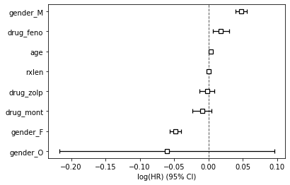

```python
ctv.plot()
```

#### Hence, here too, Gender_O, drug_mont and drug_zolp do not play any significant role in development of DR, whereas all the other covariates are significant.

```python
# With sampling

df_patient_2 = df_patient_1.sample(frac = 0.25)
df_patient_2
```

|  | ptid | start | stop | age | gender_F | gender_M | gender_O | drug_feno | drug_mont | drug_zolp | rxlen | event |
| --- | --- | --- | --- | --- | --- | --- | --- | --- | --- | --- | --- | --- |
| 344295 | 637389a729af9881f04055ac6273fe45e2a84ae4822047785ce90725759ce071 | 0 | 136 | 75 | 0 | 1 | 0 | 0 | 0 | 0 | 0 | 0 |
| 611083 | b0a40e162b23ebfb5aa2cd6b7a44595ed1d87bcee87485249ee57c9749f31bbc | 0 | 577 | 56 | 0 | 1 | 0 | 0 | 0 | 0 | 0 | 0 |
| 875489 | fce633e5cc16f6f835aef2b3ff495e8590bfcbd4d0d02f16e6de79e469408b27 | 0 | 663 | 64 | 1 | 0 | 0 | 0 | 0 | 0 | 0 | 0 |
| 662615 | bf7f8de7e2311cecd15f10624d30bf13cdbc8d4e775c68ed37d58294898391bb | 0 | 748 | 65 | 1 | 0 | 0 | 0 | 0 | 0 | 0 | 0 |
| 476688 | 89a3026a952322286ce4b07fd48fdb3981372bbdb4cbc5fc245155655ce6bb6d | 0 | 849 | 75 | 1 | 0 | 0 | 0 | 0 | 0 | 0 | 0 |
| ... | ... | ... | ... | ... | ... | ... | ... | ... | ... | ... | ... | ... |
| 761935 | dc40a353aa2d18d072c93db43f67c5da98f3825e1a0d4571e106ec537651aee5 | 0 | 7 | 64 | 1 | 0 | 0 | 0 | 0 | 0 | 0 | 1 |
| 593660 | ab93b97eefb5228b3749e9b35ba69912e4f9811125eb30c31a89da6139cf70aa | 0 | 994 | 65 | 0 | 1 | 0 | 0 | 0 | 0 | 0 | 0 |
| 787625 | e3a544b1cde01ba4441a4343df4934d88de7ef11d7551d58c915b3af684c9943 | 0 | 1672 | 75 | 1 | 0 | 0 | 0 | 0 | 0 | 0 | 0 |
| 731475 | d36b52b1ccc6793f33dc1481f60709d203212201bf24bf8b91b740bab14af7c3 | 0 | 149 | 65 | 1 | 0 | 0 | 0 | 0 | 0 | 0 | 0 |
| 706622 | cc44e609c34bc8e6e53d9d28451c4158c485609435812f5ee8c840706f04b6c0 | 0 | 768 | 65 | 0 | 1 | 0 | 0 | 0 | 0 | 0 | 0 |

200929 rows × 12 columns

```python
df_final = pd.concat([df_merged, df_patient_2])
df_final = df_final.reset_index().drop(columns = 'index')
```

```python
ctv1 = CoxTimeVaryingFitter(penalizer=0.1)
ctv1.fit(df_final, id_col="ptid", event_col="event", start_col="start", stop_col="stop", show_progress=True)
ctv1.print_summary()
```

```
Iteration 4: norm_delta = 0.00000, step_size = 1.00000, ll = -367383.57707, newton_decrement = 0.00000, seconds_since_start = 319.6Convergence completed after 4 iterations.
```

| model | lifelines.CoxTimeVaryingFitter |
| --- | --- |
| event col | 'event' |
| penalizer | 0.10000 |
| number of subjects | 283192 |
| number of periods | 1070854 |
| number of events | 30729 |
| partial log-likelihood | -367383.58 |
| time fit was run | 2020-08-25 04:28:23 UTC |

|  | coef | exp(coef) | se(coef) | coef lower 95% | coef upper 95% | exp(coef) lower 95% | exp(coef) upper 95% | z | p | -log2(p) |
| --- | --- | --- | --- | --- | --- | --- | --- | --- | --- | --- |
| age | 0.00 | 1.00 | 0.00 | 0.00 | 0.00 | 1.00 | 1.00 | 8.45 | <0.005 | 54.98 |
| gender_F | -0.03 | 0.97 | 0.01 | -0.04 | -0.02 | 0.96 | 0.98 | -5.25 | <0.005 | 22.64 |
| gender_M | 0.03 | 1.03 | 0.01 | 0.02 | 0.04 | 1.02 | 1.04 | 5.26 | <0.005 | 22.73 |
| gender_O | -0.02 | 0.98 | 0.11 | -0.24 | 0.19 | 0.79 | 1.21 | -0.22 | 0.83 | 0.27 |
| drug_feno | 0.02 | 1.02 | 0.01 | 0.01 | 0.03 | 1.01 | 1.03 | 2.98 | <0.005 | 8.43 |
| drug_mont | -0.01 | 0.99 | 0.01 | -0.03 | 0.00 | 0.97 | 1.00 | -1.60 | 0.11 | 3.18 |
| drug_zolp | -0.00 | 1.00 | 0.01 | -0.02 | 0.01 | 0.98 | 1.01 | -0.71 | 0.48 | 1.07 |
| rxlen | 0.00 | 1.00 | 0.00 | 0.00 | 0.00 | 1.00 | 1.00 | 2.35 | 0.02 | 5.73 |

| Partial AIC | 734783.15 |
| --- | --- |
| log-likelihood ratio test | 160.10 on 8 df |
| -log2(p) of ll-ratio test | 99.05 |

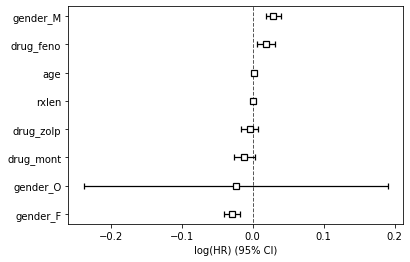

```python
ctv1.plot()
```